# Case Study 2 Deliverable TAJAR

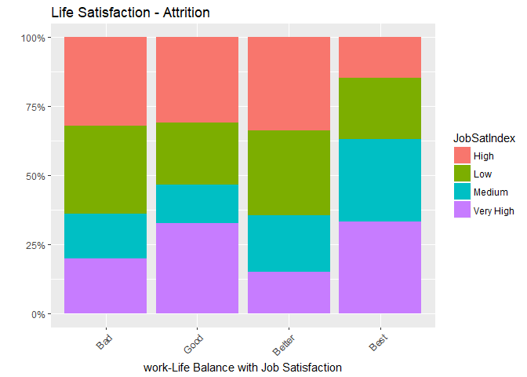

```r
#Create a visual to display.
ggplot(Satisfaction, aes(x = WorkLifeFit, fill = JobSatIndex)) + geom_bar(position = "fill") + labs(title = "Life Satisfaction - Attrition", x = "work-Life Balance with Job Satisfaction", y = "", color = "")+ scale_y_continuous(labels = scales::percent) + theme(axis.text.x = element_text(angle = 45, hjust = 1)) + scale_x_discrete(limits=c("Bad","Good","Better","Best"))
```

```r
#Create a Life Satisfaction data frame with Attrition (No), Work Life Balance and Job Satsifaction.
SatisfactionN <- subset(attritionDF, Attrition=="No", select=c(JobSatIndex, WorkLifeFit, Attrition))
head(SatisfactionN)
```

```
## # A tibble: 6 x 3
##   JobSatIndex WorkLifeFit Attrition
##   <chr>       <chr>       <chr>
## 1 Medium      Better      No
## 2 High        Better      No
## 3 Medium      Better      No
## 4 Very High   Good        No
## 5 Low         Good        No
## 6 High        Better      No
```

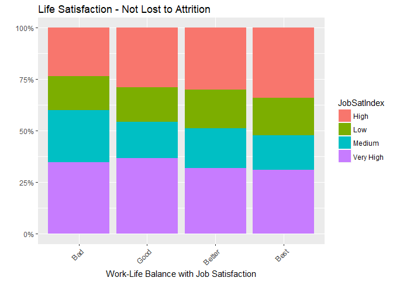

```r
#Create a visual to display.
ggplot(SatisfactionN, aes(x = WorkLifeFit, fill = JobSatIndex)) + geom_bar(position = "fill") + labs(title = "Life Satisfaction - Not Lost to Attrition", x = "Work-Life Balance with Job Satisfaction", y = "", color = "")+ scale_y_continuous(labels = scales::percent) + theme(axis.text.x = element_text(angle = 45, hjust = 1)) + scale_x_discrete(limits=c("Bad","Good","Better","Best"))
```

TAJAR was asked specifically to investigate the attrition rate as it related to Job Role of the employee. When examined, it was found that, with one notable exception, job satisfaction did not have an effect on attrition. However, in the Human Resources Department, it is predicted that the low job satisfaction likely has some role in the high department attrition rate. Additionally, it was found that working overtime also did not have a significant effect on job satisfaction, although it did on attrition. And, when separated by job role, working overtime did not significantly predict an employee leaving. However, the jobs with the lowest monthly income had a higher turnover rate, which is reflected in overall department departures as well.

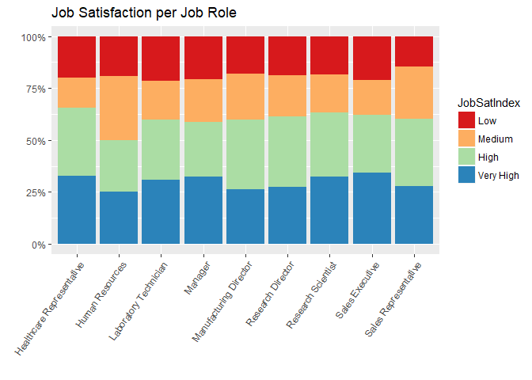

```r
#Job Satisfaction vs Job Role in %
attritionDF$JobSatIndex <- factor(attritionDF$JobSatIndex, levels = c("Low", "Medium", "High", "Very High"))
ggplot(attritionDF, aes(JobRole, fill = JobSatIndex)) + geom_bar(position = "fill")  + labs(title = "Job Satisfaction per Job Role" , y = "", x = "") + theme(axis.text.x = element_text(angle = 55, hjust = 1)) + scale_fill_brewer(palette="Spectral") + scale_y_continuous(labels = scales::percent)
```

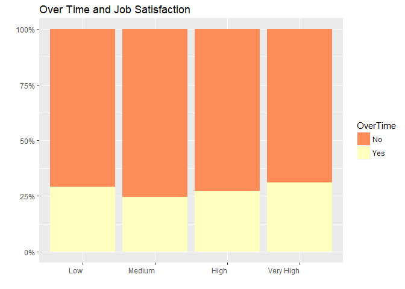

```r
#Over Time vs Job Satisfaction in %
ggplot(attritionDF, aes(JobSatIndex, fill = OverTime)) + geom_bar(position = "fill")  + labs(title = "Over Time and Job Satisfaction" , y = "", x = "") + theme(axis.text.x = element_text(angle = 0, hjust = 1)) + scale_fill_brewer(palette="Spectral") + scale_y_continuous(labels = scales::percent)
```

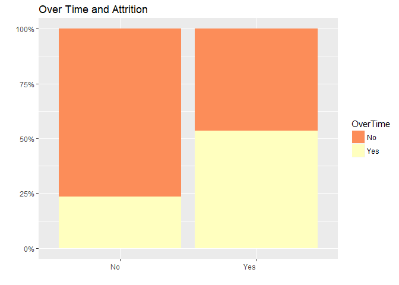

```r
attritionDF$JobSatIndex <- as.character(attritionDF$JobSatIndex)

#Over Time vs Attrition in %
ggplot(attritionDF, aes(Attrition, fill = OverTime)) + geom_bar(position = "fill")  + labs(title = "Over Time and Attrition" , y = "", x = "") + theme(axis.text.x = element_text(angle = 0, hjust = 1)) + scale_fill_brewer(palette="Spectral") + scale_y_continuous(labels = scales::percent)
```

```r
attritionDF$Attrition <- as.character(attritionDF$Attrition)

#What was the percentage of people who worked overtime that left, by JobRole?
Attrition <- filter(attritionDF, Attrition == "Yes")
attrition.aggregate <- count(Attrition, JobRole, OverTime)
attrition.percentages <- attrition.aggregate %>% group_by(JobRole) %>% mutate(totalInRole=sum(n)) %>% group_by(OverTime) %>% mutate(percentage=paste0(round(100*n/totalInRole,2),'%'))
attrition.percentages
```

```
## # A tibble: 18 x 5
## # Groups:   OverTime [2]
##    JobRole                   OverTime     n totalInRole percentage
##    <chr>                     <chr>    <int>       <int> <chr>
##  1 Healthcare Representative No           7           9 77.78%
##  2 Healthcare Representative Yes          2           9 22.22%
##  3 Human Resources           No           7          12 58.33%
##  4 Human Resources           Yes          5          12 41.67%
##  5 Laboratory Technician     No          31          62 50%
##  6 Laboratory Technician     Yes         31          62 50%
##  7 Manager                   No           1           5 20%
##  8 Manager                   Yes          4           5 80%
##  9 Manufacturing Director    No           6          10 60%
## 10 Manufacturing Director    Yes          4          10 40%
## 11 Research Director         No           1           2 50%
## 12 Research Director         Yes          1           2 50%
## 13 Research Scientist        No          14          47 29.79%
## 14 Research Scientist        Yes         33          47 70.21%
## 15 Sales Executive           No          26          57 45.61%
## 16 Sales Executive           Yes         31          57 54.39%
## 17 Sales Representative      No          17          33 51.52%
## 18 Sales Representative      Yes         16          33 48.48%
```

```r
#How many people left per JobRole?
count(attritionDF, JobRole)
```

```
## # A tibble: 9 x 2
##   JobRole                       n
##   <chr>                     <int>
## 1 Healthcare Representative   131
## 2 Human Resources              52
## 3 Laboratory Technician       259
## 4 Manager                     102
## 5 Manufacturing Director      145
## 6 Research Director            80
## 7 Research Scientist          292
## 8 Sales Executive             326
## 9 Sales Representative         83
```

```r
count(filter(attritionDF, Attrition == "Yes"), JobRole)
```

```
## # A tibble: 9 x 2
##   JobRole                       n
##   <chr>                     <int>
## 1 Healthcare Representative     9
## 2 Human Resources              12
## 3 Laboratory Technician        62
## 4 Manager                       5
## 5 Manufacturing Director       10
## 6 Research Director             2
## 7 Research Scientist           47
## 8 Sales Executive              57
## 9 Sales Representative         33
```

```r
#Total Monthly income per Job Role
testDF <- dplyr::group_by(attritionDF, JobRole)
summarize(testDF, avgMonthlySalary = mean(MonthlyInco))
```

```
## # A tibble: 9 x 2
##   JobRole                   avgMonthlySalary
##   <chr>                                <dbl>
## 1 Healthcare Representative            7529.
## 2 Human Resources                      4236.
## 3 Laboratory Technician                3237.
## 4 Manager                             17182.
## 5 Manufacturing Director               7295.
## 6 Research Director                   16034.
## 7 Research Scientist                   3240.
## 8 Sales Executive                      6924.
## 9 Sales Representative                 2626
```

When looking at job satisfaction, which executive leadership hypothesized would have a significant effect on attrition, the opposite was found to be true. In general, job satisfaction was found to be consistent across all ages and Job Roles, and when those who left the company were examined, those most likely to leave (ages 18-21 and those with the Job Roles of Sales Representatives, Lab technicians, and non-manage Human Resources Department Workers) were more likely to have a higher job satisfaction rating (with the notable and previously noted exception of Human Resources).

```r
#Plot Job Satisfaction by Age- ATTRITION YES
#Create a Job Satisfaction data frame with Attrition (Yes), Work Life Balance and Job Satsifaction.
JobSatisfaction <- subset(attritionDF, Attrition=="Yes", select=c(JobSatIndex, WorkLifeFit, Attrition, Age))
head(Satisfaction)
```

```
## # A tibble: 6 x 3
##   JobSatIndex WorkLifeFit Attrition
##   <chr>       <chr>       <chr>
## 1 Very High   Bad         Yes
## 2 High        Better      Yes
## 3 High        Better      Yes
## 4 Low         Better      Yes
## 5 Low         Better      Yes
## 6 Low         Better      Yes
```

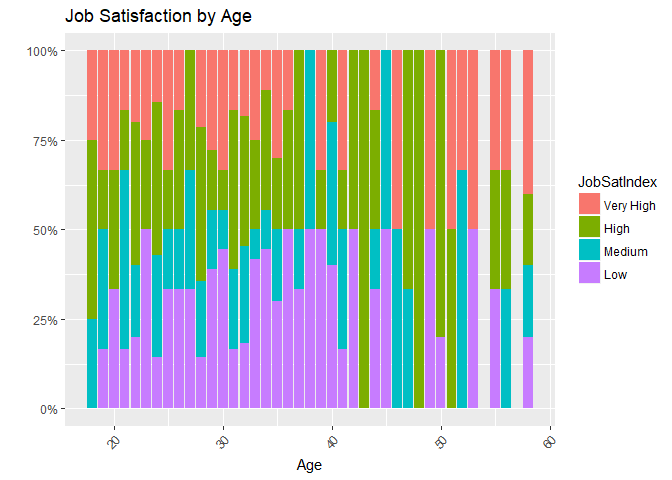

```r
#organize factors for the plot
JobSatisfaction$JobSatIndex <- factor(JobSatisfaction$JobSatIndex, levels = c("Very High", "High", "Medium", "Low"))

#Plot JobSatIndex by Age
ggplot(JobSatisfaction, aes(x = Age, fill = JobSatIndex)) + geom_bar(position = "fill") + labs(title = "Job Satisfaction by Age", x = "Age", y = "", color = "")+ scale_y_continuous(labels = scales::percent) + theme(axis.text.x = element_text(angle = 45, hjust = 1))
```

```r
#Plot Job Satisfaction by Age
#Create a Job Satisfaction data frame with Attrition (Yes), Work Life Balance and Job Satsifaction.
JobSatisfactionT <- subset(attritionDF, select=c(JobSatIndex, WorkLifeFit, Attrition, Age))
head(JobSatisfactionT)
```

```
## # A tibble: 6 x 4
##   JobSatIndex WorkLifeFit Attrition   Age
##   <chr>       <chr>       <chr>     <dbl>
## 1 Very High   Bad         Yes          41
## 2 Medium      Better      No           49
## 3 High        Better      Yes          37
## 4 High        Better      No           33
## 5 Medium      Better      No           27
## 6 Very High   Good        No           32
```

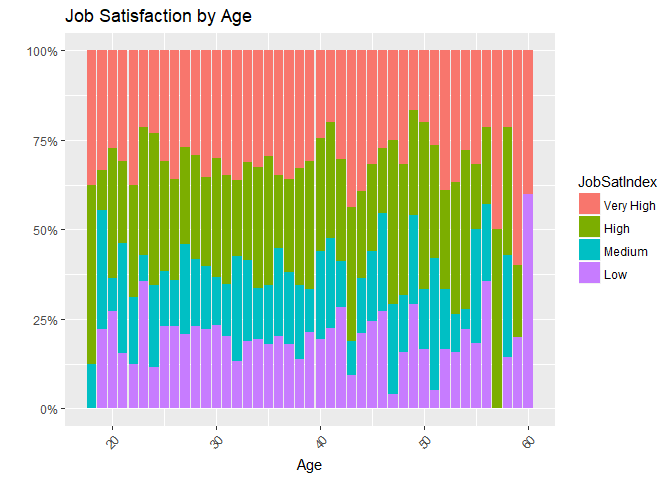

```r
#organize factors for the plot
JobSatisfactionT$JobSatIndex <- factor(JobSatisfactionT$JobSatIndex, levels = c("Very High", "High", "Medium", "Low"))

#Plot JobSatIndex by Age
ggplot(JobSatisfactionT, aes(x = Age, fill = JobSatIndex)) + geom_bar(position = "fill") + labs(title = "Job Satisfaction by Age", x = "Age", y = "", color = "")+ scale_y_continuous(labels = scales::percent) + theme(axis.text.x = element_text(angle = 45, hjust = 1))
```

## Evaluation, Results

```r
# Create a copy of original DataFrame
formattedAttrDF <- data.frame(attritionDF)
str(formattedAttrDF)
```

```
## 'data.frame':    1470 obs. of  35 variables:
##  $ Age         : num  41 49 37 33 27 32 59 30 38 36 ...
##  $ Attrition   : chr  "Yes" "No" "Yes" "No" ...
##  $ WorkTravel  : chr  "Travel_Rarely" "Travel_Frequently" "Travel_Rarely" "Travel_Frequently" ...
##  $ DailyRate   : num  1102 279 1373 1392 591 ...
##  $ Department  : chr  "Sales" "Research & Development" "Research & Development" "Research & Development" ...
##  $ DistFromHome: num  1 8 2 3 2 2 3 24 23 27 ...
##  $ Education   : chr  "College" "Below College" "College" "Master" ...
##  $ FieldOfStudy: chr  "Life Sciences" "Life Sciences" "Other" "Life Sciences" ...
##  $ Headcount   : num  1 1 1 1 1 1 1 1 1 1 ...
##  $ EmployeeID  : num  1 2 4 5 7 8 10 11 12 13 ...
##  $ EnvrSatIndex: chr  "Medium" "High" "Very High" "Very High" ...
##  $ Gender      : chr  "Female" "Male" "Male" "Female" ...
##  $ HourlyRate  : num  94 61 92 56 40 79 81 67 44 94 ...
##  $ JobInvolv   : chr  "High" "Medium" "Medium" "High" ...
```

[output cut: 21 more lines]

```r
as.data.frame(apply(formattedAttrDF, 2, function(x) length(unique(x))))
```

```
##              apply(formattedAttrDF, 2, function(x) length(unique(x)))
## Age                                                                43
## Attrition                                                           2
## WorkTravel                                                          3
## DailyRate                                                         886
## Department                                                          3
## DistFromHome                                                       29
## Education                                                           5
## FieldOfStudy                                                        6
## Headcount                                                           1
## EmployeeID                                                       1470
## EnvrSatIndex                                                        4
## Gender                                                              2
## HourlyRate                                                         71
## JobInvolv                                                           4
## JobLevel                                                            5
## JobRole                                                             9
## JobSatIndex                                                         4
## MaritalState                                                        3
## MonthlyInco                                                      1349
## MonthlyRate                                                      1427
## NumPriorComp                                                       10
## Over18                                                              1
## OverTime                                                            2
## PctSalaryInc                                                       15
## PerfRating                                                          2
## RelpSatIndex                                                        4
## StdHours                                                            1
## StockOptLvl                                                         4
## TotWorkExp                                                         40
## TrainedLstYr                                                        7
## WorkLifeFit                                                         4
## YrsAtCompany                                                       37
## YrsInRole                                                          19
## LastPromoted                                                       16
## YrsWithMgr                                                         18
```

```r
# Converting relevant Character Variables to Factors since these have levels.
convertToFactors <- c("Attrition", "WorkTravel", "Department", "Education", "FieldOfStudy", "EnvrSatIndex", "Gender", "JobInvolv", "JobLevel", "JobRole", "JobSatIndex" , "MaritalState", "Over18", "OverTime", "PerfRating", "RelpSatIndex", "StockOptLvl", "WorkLifeFit")
for(columnName in convertToFactors){
  formattedAttrDF[,columnName] <- as.factor(formattedAttrDF[,columnName])
}
# Extra Debug--Remove
lapply(formattedAttrDF, function(x){if(is.factor(x)) levels(x)})
```

```
## $Age
## NULL
##
## $Attrition
## [1] "No"  "Yes"
##
## $WorkTravel
## [1] "Non-Travel"        "Travel_Frequently" "Travel_Rarely"
##
## $DailyRate
## NULL
##
## $Department
## [1] "Human Resources"        "Research & Development"
## [3] "Sales"
##
## $DistFromHome
## NULL
##
## $Education
## [1] "Bachelor"      "Below College" "College"       "Doctor"
## [5] "Master"
##
## $FieldOfStudy
## [1] "Human Resources"  "Life Sciences"    "Marketing"
## [4] "Medical"          "Other"            "Technical Degree"
##
## $Headcount
## NULL
##
## $EmployeeID
## NULL
##
## $EnvrSatIndex
## [1] "High"      "Low"       "Medium"    "Very High"
##
## $Gender
## [1] "Female" "Male"
##
## $HourlyRate
```

[output cut: 56 more lines]

```
##
## $WorkLifeFit
## [1] "Bad"    "Best"   "Better" "Good"
##
## $YrsAtCompany
## NULL
##
## $YrsInRole
## NULL
##
## $LastPromoted
## NULL
##
## $YrsWithMgr
## NULL
```

```r
levelsInfoDf <- read.xlsx2(file = "CaseStudy2-data.xlsx",sheetName = "Data Definitions", startRow = 3, header = F)
str(levelsInfoDf)
```

```
## 'data.frame':    35 obs. of  2 variables:
##  $ X1: Factor w/ 8 levels "","Education",..: 2 1 1 1 1 1 3 1 1 1 ...
##  $ X2: Factor w/ 16 levels "","1 'Bad'","1 'Below College'",..: 3 5 8 13 16 1 4 7 11 15 ...
```

```r
levelsInfoDf[ , c("levelNo", "levelName")] <- colsplit(levelsInfoDf$X2, " ", c("levelNo", "levelName"))
levelsInfoDf$levelName <- gsub('[[:punct:]]+','',levelsInfoDf$levelName)
levelsInfoDf
```

```
##                          X1                X2 levelNo     levelName
## 1                 Education 1 'Below College'       1 Below College
## 2                                 2 'College'       2       College
## 3                                3 'Bachelor'       3      Bachelor
## 4                                  4 'Master'       4        Master
## 5                                  5 'Doctor'       5        Doctor
## 6                                                  NA
## 7   EnvironmentSatisfaction           1 'Low'       1           Low
## 8                                  2 'Medium'       2        Medium
## 9                                    3 'High'       3          High
## 10                              4 'Very High'       4     Very High
## 11                                                 NA
## 12           JobInvolvement           1 'Low'       1           Low
## 13                                 2 'Medium'       2        Medium
## 14                                   3 'High'       3          High
```

[output cut: 21 more lines]

```r
# Give Meaningful Category Names to Levels of factors that have levels as "1", "2" etc
# This will be done based upon the data definations present in the case study sheet
levels(formattedAttrDF$Education) <- levelsInfoDf[1:5, "levelName"]
levels(formattedAttrDF$EnvrSatIndex) <- levelsInfoDf[7:10, "levelName"]
levels(formattedAttrDF$JobInvolv) <- levelsInfoDf[12:15, "levelName"]
levels(formattedAttrDF$JobSatIndex) <- levelsInfoDf[17:20, "levelName"]
levels(formattedAttrDF$PerfRating) <- levelsInfoDf[22:25, "levelName"]
levels(formattedAttrDF$RelpSatIndex) <- levelsInfoDf[27:30, "levelName"]
levels(formattedAttrDF$WorkLifeFit) <- levelsInfoDf[32:35, "levelName"]
# Assigning Levels to variables Job Level and Stock Options as these are not mentioned in data defination sheet
levels(formattedAttrDF$JobLevel) <- c("Entry", "Experienced", "First-Level Management", "Middle-Level Management", "Top-Level Management")
levels(formattedAttrDF$WorkTravel) <- c("Non-Travel", "Travel_Rarely", "Travel_Frequently")
lapply(formattedAttrDF, function(x){if(is.factor(x)) levels(x)})
```

```
## $Age
## NULL
##
## $Attrition
## [1] "No"  "Yes"
##
## $WorkTravel
## [1] "Non-Travel"        "Travel_Rarely"     "Travel_Frequently"
##
## $DailyRate
## NULL
##
## $Department
## [1] "Human Resources"        "Research & Development"
## [3] "Sales"
##
## $DistFromHome
## NULL
##
## $Education
## [1] "Below College" "College"       "Bachelor"      "Master"
## [5] "Doctor"
##
## $FieldOfStudy
## [1] "Human Resources"  "Life Sciences"    "Marketing"
## [4] "Medical"          "Other"            "Technical Degree"
##
## $Headcount
## NULL
##
## $EmployeeID
## NULL
##
## $EnvrSatIndex
## [1] "Low"       "Medium"    "High"      "Very High"
##
## $Gender
## [1] "Female" "Male"
##
## $HourlyRate
```

[output cut: 58 more lines]

```
##
## $WorkLifeFit
## [1] "Bad"    "Good"   "Better" "Best"
##
## $YrsAtCompany
## NULL
##
## $YrsInRole
## NULL
##
## $LastPromoted
## NULL
##
## $YrsWithMgr
## NULL
```

```r
all(complete.cases(formattedAttrDF))
```

```
## [1] TRUE
```